# Prediksi Harga Saham INDOFOOD Model ARCH

Rika Ajeng Finatih

2024-11-02

# JUDUL

Prediksi Harga Saham PT. Indofood Sukses Makmur TBK (INDF) Menggunakan Model ARCH (Autoregressive Conditional Heteroskedasticity) Periode Januari 2020- Oktober 2024

# Deskripsi Dataset

Dataset yang digunakan untuk prediksi harga saham PT. Indofood Sukses Makmur Tbk (INDF) mencakup periode dari Januari 2020 hingga Oktober 2024. Data ini diambil dari sumber keuangan terpercaya seperti Yahoo Finance atau Bloomberg, dan terdiri dari beberapa atribut penting. Atribut tersebut meliputi tanggal perdagangan, harga pembukaan, harga penutupan, harga tertinggi, harga terendah, volume perdagangan, dan return harian. Tanggal mencatat hari kerja dalam periode analisis, sedangkan harga pembukaan dan harga penutupan mencerminkan harga saham pada saat pembukaan dan penutupan perdagangan setiap hari. Harga tertinggi dan terendah menunjukkan fluktuasi harga saham dalam sehari, dan volume perdagangan mencatat jumlah saham yang diperdagangkan. Return harian dihitung sebagai persentase perubahan harga dari hari sebelumnya. Dataset ini akan dianalisis untuk memahami pola dan tren harga saham serta untuk membangun model ARCH (Autoregressive Conditional Heteroskedasticity), yang berguna dalam memprediksi volatilitas harga saham INDF.

# Import Library

```r
library(forecast)
library(tseries)
library(TSA)
library(astsa)
library(lmtest)
library(aTSA)
library(fGarch)
library(readxl)
library(xts)
library(rugarch)
library(quantmod)
library(tseries)
library(rugarch)
library(zoo)
library(kableExtra)
```

# Import Dataset

```r
# Mengimport Data
dtindf <- read.csv("C:/Users/RIKA/Downloads/Data Historis INDF.csv")#
#dtindf <- dtindf[,-c(2,3,4,6,7)] # Menghapus kolom ke 2,3,4,6,dan 7
dtindf
```

```
##         Tanggal Terakhir Pembukaan Tertinggi Terendah   Vol. Perubahan.
## 1    31/10/2024    7.600     7.525     7.650    7.500 25,84M      1,67%
## 2    30/10/2024    7.475     7.575     7.575    7.450  9,56M     -1,32%
## 3    29/10/2024    7.575     7.500     7.575    7.450 10,86M      0,66%
## 4    28/10/2024    7.525     7.500     7.525    7.375  4,96M      0,33%
## 5    25/10/2024    7.500     7.575     7.575    7.450  6,07M     -0,33%
## 6    24/10/2024    7.525     7.500     7.550    7.475  9,34M      0,33%
## 7    23/10/2024    7.500     7.450     7.550    7.425 19,21M      1,01%
## 8    22/10/2024    7.425     7.400     7.475    7.350 14,44M      0,34%
## 9    21/10/2024    7.400     7.400     7.425    7.325  8,43M     -0,34%
## 10   18/10/2024    7.425     7.225     7.475    7.200 23,78M      3,48%
## 11   17/10/2024    7.175     7.175     7.275    7.175  5,42M      0,00%
## 12   16/10/2024    7.175     7.250     7.275    7.150  8,88M     -0,35%
## 13   15/10/2024    7.200     7.050     7.250    7.050 17,97M      2,13%
## 14   14/10/2024    7.050     7.000     7.100    6.975  3,97M      0,71%
```

[output cut: 1158 more lines]

```r
# Konversi kolom Tanggal menjadi tipe Date
dtindf$Tanggal <- as.Date(dtindf$Tanggal, format = "%Y-%m-%d")

# Pastikan rentang tanggal konsisten, misalnya antara 2022-10-06 hingga 2024-10-05
dates <- data.frame(Tanggal = seq(as.Date("2020-01-02"), as.Date("2024-10-31"), by = "days"))

# Menggabungkan data dtindf dengan data dates untuk memastikan semua tanggal ada
allindf <- merge(dates, dtindf, by = "Tanggal", all = TRUE)

# Mengisi nilai NA dengan Last Observation Carried Forward (LOCF)
allindf <- na.locf(allindf, fromLast = FALSE)

# Tampilkan subset data untuk memastikan
kableExtra::kable(head(allindf, 10), caption = "Subset Data Harian Harga Saham")
```

Subset Data Harian Harga Saham

|  | Tanggal | Terakhir | Pembukaan | Tertinggi | Terendah | Vol. | Perubahan. |
| --- | --- | --- | --- | --- | --- | --- | --- |
| 1766 | 2024-10-31 | 7.600 | 7.525 | 7.650 | 7.500 | 25,84M | 1,67% |
| 1767 | 2024-10-31 | 7.475 | 7.575 | 7.575 | 7.450 | 9,56M | -1,32% |
| 1768 | 2024-10-31 | 7.575 | 7.500 | 7.575 | 7.450 | 10,86M | 0,66% |
| 1769 | 2024-10-31 | 7.525 | 7.500 | 7.525 | 7.375 | 4,96M | 0,33% |
| 1770 | 2024-10-31 | 7.500 | 7.575 | 7.575 | 7.450 | 6,07M | -0,33% |
| 1771 | 2024-10-31 | 7.525 | 7.500 | 7.550 | 7.475 | 9,34M | 0,33% |
| 1772 | 2024-10-31 | 7.500 | 7.450 | 7.550 | 7.425 | 19,21M | 1,01% |
| 1773 | 2024-10-31 | 7.425 | 7.400 | 7.475 | 7.350 | 14,44M | 0,34% |
| 1774 | 2024-10-31 | 7.400 | 7.400 | 7.425 | 7.325 | 8,43M | -0,34% |
| 1775 | 2024-10-31 | 7.425 | 7.225 | 7.475 | 7.200 | 23,78M | 3,48% |

```r
# Mengubah data menjadi tseries
saham_indf <- ts(dtindf$Terakhir, frequency = 365, start = c(2020,2)) # mengubah kolom dtindf menjadi series dengan frequency menunjukan bahwa data yg diamati dalam harian, dimulai dari 2013 tanggal 2 Januari
saham_indf
```

```
## Time Series:
## Start = c(2020, 2)
## End = c(2023, 78)
## Frequency = 365
##    [1] 7.600 7.475 7.575 7.525 7.500 7.525 7.500 7.425 7.400 7.425 7.175 7.175
##   [13] 7.200 7.050 7.000 7.025 6.925 7.000 6.925 7.050 7.100 7.075 7.175 7.050
##   [25] 7.175 7.225 7.175 7.175 7.100 7.150 7.075 7.075 7.100 7.100 7.150 7.000
##   [37] 7.050 6.925 7.025 6.975 6.700 6.775 6.725 6.850 6.800 6.825 6.800 6.850
##   [49] 6.700 6.650 6.625 6.525 6.450 6.525 6.475 6.500 6.325 6.250 6.275 6.225
##   [61] 6.125 6.100 6.050 6.100 6.150 6.125 6.050 6.075 6.125 6.100 6.000 6.100
##   [73] 6.025 6.075 6.075 6.050 5.950 5.975 5.950 5.925 6.000 5.950 6.200 6.125
##   [85] 6.075 6.100 6.100 6.100 6.075 6.025 5.900 5.950 5.925 5.975 5.925 5.925
##   [97] 6.075 6.125 6.200 6.125 6.175 6.200 6.200 6.125 6.100 6.050 5.875 6.050
##  [109] 6.125 6.125 6.125 6.150 6.150 6.225 6.150 6.150 6.100 6.175 6.100 6.200
##  [121] 6.150 6.225 6.225 6.225 6.250 6.175 6.050 6.200 6.050 6.025 6.150 6.100
```

[output cut: 87 more lines]

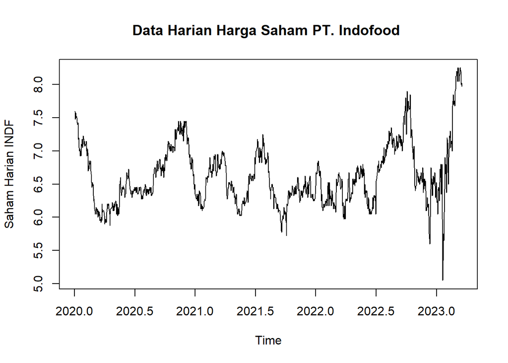

```r
# Plot tseries
plot(saham_indf, main = "Data Harian Harga Saham PT. Indofood ", ylab="Saham Harian INDF")
```

# Cek Kestasioneran Data

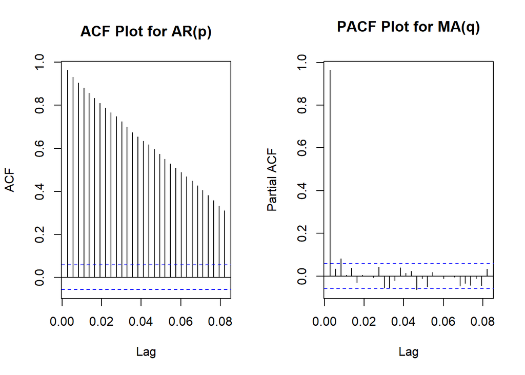

```r
par(mfrow=c(1,2))
acf(saham_indf, main = "ACF Plot for AR(p)")
pacf(saham_indf, main = "PACF Plot for MA(q)")
```

```r
#adf.test(saham_indf) # Plot ACF dan PACF diatas menunjukan data, tidak stationer, maka akan dibuktikan dengan adf test
```

Analisis : Hasil dari visualisasi menunjukkan bahwa data tidak stasioner terhadap rataan, maka akan dilakukan differencing.

# Differencing

```r
saham.diff<-diff(saham_indf)
```

# Uji kembali kestasioneran

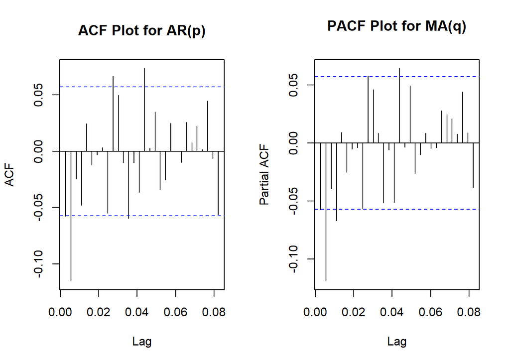

```r
par(mfrow=c(1,2))
acf(saham.diff, main = "ACF Plot for AR(p)")
pacf(saham.diff, main = "PACF Plot for MA(q)")
```

```r
adf.test(saham.diff)
```

```
## Augmented Dickey-Fuller Test
## alternative: stationary
##
## Type 1: no drift no trend
##      lag   ADF p.value
## [1,]   0 -36.2    0.01
## [2,]   1 -28.0    0.01
## [3,]   2 -22.5    0.01
## [4,]   3 -20.1    0.01
## [5,]   4 -17.1    0.01
## [6,]   5 -15.7    0.01
## [7,]   6 -14.3    0.01
## Type 2: with drift no trend
##      lag   ADF p.value
## [1,]   0 -36.2    0.01
## [2,]   1 -28.0    0.01
## [3,]   2 -22.5    0.01
## [4,]   3 -20.1    0.01
## [5,]   4 -17.1    0.01
## [6,]   5 -15.7    0.01
## [7,]   6 -14.3    0.01
## Type 3: with drift and trend
##      lag   ADF p.value
## [1,]   0 -36.2    0.01
## [2,]   1 -28.0    0.01
## [3,]   2 -22.5    0.01
## [4,]   3 -20.1    0.01
## [5,]   4 -17.2    0.01
## [6,]   5 -15.7    0.01
## [7,]   6 -14.4    0.01
## ----
## Note: in fact, p.value = 0.01 means p.value <= 0.01
```

Analisis : Setelah dilakukan differencing(1), berdasarkan ADF Test nilai p-value < alpha - 0,05. Sehingga, pada taraf nyata 5% *cukup bukti* untuk menyatakan bahwa data stasioner.

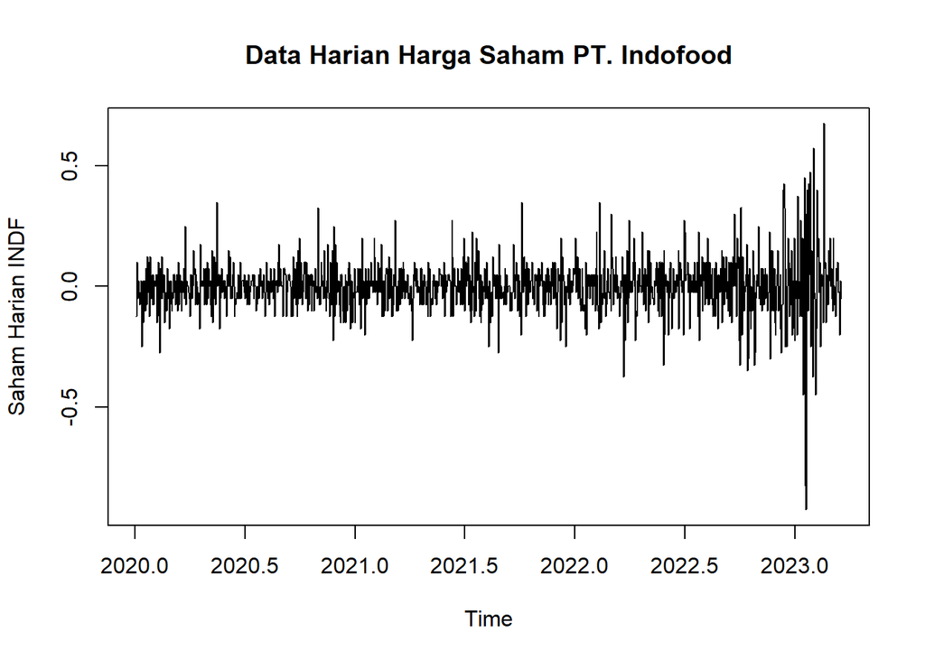

```r
# plot setelah stationer
plot(saham.diff, main = "Data Harian Harga Saham PT. Indofood", ylab="Saham Harian INDF" )
```

# ARIMA

## Penentuan Ordo

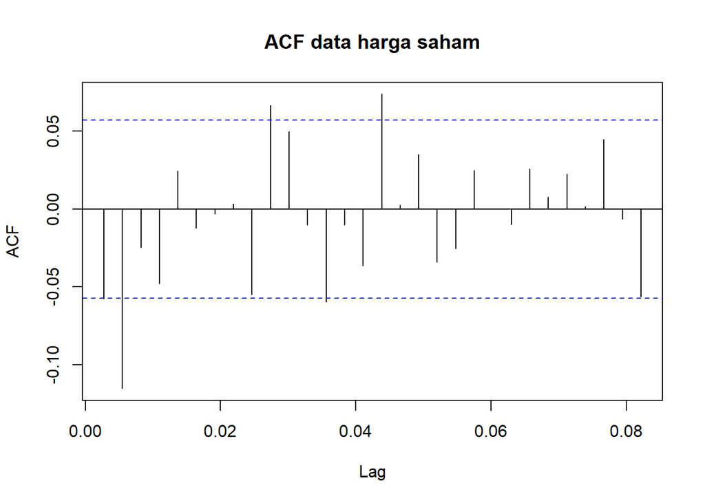

```r
# Identifikasi Model ARIMA dengan ACF, PACF, dan EACF
acf(saham.diff, main="ACF data harga saham")
```

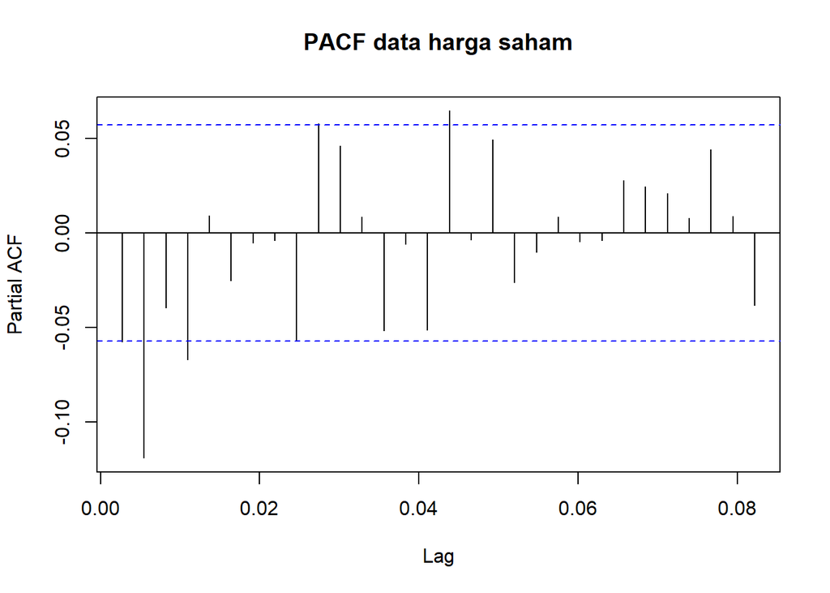

```r
pacf(saham.diff, main="PACF data harga saham")
```

```r
eacf(saham.diff)
```

```
## AR/MA
##   0 1 2 3 4 5 6 7 8 9 10 11 12 13
## 0 o x o o o o o o o x o  o  x  o
## 1 x x o o o o o o o x x  o  o  o
## 2 x x o o o o o o o x o  o  x  o
## 3 x x x o o o o o o o o  o  o  o
## 4 x x x x o o o o o o o  o  o  o
## 5 x x x o x o o o o o o  o  o  o
## 6 x x o x x o o o o o o  o  o  o
## 7 x o x o x x o o o o o  o  o  o
```

Analisis : Berdasarkan plot di atas, didapatkan kandidat model ARIMA sebagai berikut:ARIMA(0,1,0), ARIMA(0,1,2), ARIMA(1,1,2), ARIMA(0,1,3), ARIMA(1,1,3), dll.

## Pemilihan Model Terbaik

```r
model1 <- arima(saham.diff,order = c(0,1,0))
model1
```

```
##
## Call:
## arima(x = saham.diff, order = c(0, 1, 0))
##
##
## sigma^2 estimated as 0.02725:  log likelihood = 447.41,  aic = -894.82
```

```r
model2 <- arima(saham.diff,order = c(0,1,2))
model2
```

```
##
## Call:
## arima(x = saham.diff, order = c(0, 1, 2))
##
## Coefficients:
##           ma1     ma2
##       -1.0747  0.0747
## s.e.   0.0338  0.0336
##
## sigma^2 estimated as 0.01284:  log likelihood = 884.23,  aic = -1764.46
```

```r
model3 <- arima(saham.diff,order = c(1,1,2))
model3
```

```
##
## Call:
## arima(x = saham.diff, order = c(1, 1, 2))
##
## Coefficients:
##           ar1      ma1      ma2
##       -0.7461  -0.2383  -0.7617
## s.e.   0.1661   0.1598   0.1598
##
## sigma^2 estimated as 0.01288:  log likelihood = 882.08,  aic = -1758.16
```

```r
model4 <- arima(saham.diff,order = c(0,1,3))
model4
```

```
##
## Call:
## arima(x = saham.diff, order = c(0, 1, 3))
##
## Coefficients:
##           ma1      ma2     ma3
##       -1.0734  -0.0606  0.1341
## s.e.   0.0296   0.0428  0.0305
##
## sigma^2 estimated as 0.01263:  log likelihood = 893.61,  aic = -1781.22
```

```r
model5 <- arima(saham.diff,order = c(1,1,3))
model5
```

```
##
## Call:
## arima(x = saham.diff, order = c(1, 1, 3))
##
## Coefficients:
##          ar1      ma1     ma2     ma3
##       0.3002  -1.3647  0.2529  0.1120
## s.e.  0.2301   0.2298  0.2615  0.0418
##
## sigma^2 estimated as 0.01262:  log likelihood = 894.35,  aic = -1780.71
```

```r
Model <- c("ARIMA (0,1,0)","ARIMA (0,1,2)","ARIMA (1,1,2)","ARIMA (0,1,3)","ARIMA(1,1,3)")
AIC <- c(model1$aic,model2$aic,model3$aic,model4$aic,model5$aic)
Akurasi <- data.frame(Model,AIC)
kableExtra::kable(Akurasi)
```

| Model | AIC |
| --- | --- |
| ARIMA (0,1,0) | -894.822 |
| ARIMA (0,1,2) | -1764.456 |
| ARIMA (1,1,2) | -1758.159 |
| ARIMA (0,1,3) | -1781.218 |
| ARIMA(1,1,3) | -1780.706 |

```r
paste("Model yang terbaik berdasarkan akurasi adalah model",Akurasi$Model[which.min(Akurasi[,"AIC"])])
```

```
## [1] "Model yang terbaik berdasarkan akurasi adalah model ARIMA (0,1,3)"
```

## Penentuan Menggunakan Auto ARIMA

```r
auto.arima(saham_indf,trace = T)
```

```
##
##  Fitting models using approximations to speed things up...
##
##  ARIMA(2,1,2)(1,0,1)[365] with drift         : Inf
##  ARIMA(0,1,0)             with drift         : -1764.728
##  ARIMA(1,1,0)(1,0,0)[365] with drift         : Inf
##  ARIMA(0,1,1)(0,0,1)[365] with drift         : Inf
##  ARIMA(0,1,0)                                : -1766.726
##  ARIMA(0,1,0)(1,0,0)[365] with drift         : Inf
##  ARIMA(0,1,0)(0,0,1)[365] with drift         : Inf
##  ARIMA(0,1,0)(1,0,1)[365] with drift         : Inf
##  ARIMA(1,1,0)             with drift         : -1766.825
##  ARIMA(1,1,0)(0,0,1)[365] with drift         : Inf
##  ARIMA(1,1,0)(1,0,1)[365] with drift         : Inf
##  ARIMA(2,1,0)             with drift         : -1781.192
##  ARIMA(2,1,0)(1,0,0)[365] with drift         : Inf
##  ARIMA(2,1,0)(0,0,1)[365] with drift         : Inf
##  ARIMA(2,1,0)(1,0,1)[365] with drift         : Inf
##  ARIMA(3,1,0)             with drift         : -1780.267
##  ARIMA(2,1,1)             with drift         : -1783.278
##  ARIMA(2,1,1)(1,0,0)[365] with drift         : Inf
##  ARIMA(2,1,1)(0,0,1)[365] with drift         : Inf
##  ARIMA(2,1,1)(1,0,1)[365] with drift         : Inf
##  ARIMA(1,1,1)             with drift         : -1780.699
##  ARIMA(3,1,1)             with drift         : -1781.986
##  ARIMA(2,1,2)             with drift         : -1783.716
##  ARIMA(2,1,2)(1,0,0)[365] with drift         : Inf
##  ARIMA(2,1,2)(0,0,1)[365] with drift         : Inf
##  ARIMA(1,1,2)             with drift         : -1784.311
##  ARIMA(1,1,2)(1,0,0)[365] with drift         : Inf
##  ARIMA(1,1,2)(0,0,1)[365] with drift         : Inf
##  ARIMA(1,1,2)(1,0,1)[365] with drift         : Inf
##  ARIMA(0,1,2)             with drift         : -1784.919
##  ARIMA(0,1,2)(1,0,0)[365] with drift         : Inf
##  ARIMA(0,1,2)(0,0,1)[365] with drift         : Inf
##  ARIMA(0,1,2)(1,0,1)[365] with drift         : Inf
##  ARIMA(0,1,1)             with drift         : -1767.823
##  ARIMA(0,1,3)             with drift         : -1783.737
##  ARIMA(1,1,3)             with drift         : -1782.297
##  ARIMA(0,1,2)                                : -1786.915
##  ARIMA(0,1,2)(1,0,0)[365]                    : Inf
##  ARIMA(0,1,2)(0,0,1)[365]                    : Inf
##  ARIMA(0,1,2)(1,0,1)[365]                    : Inf
##  ARIMA(0,1,1)                                : -1769.822
##  ARIMA(1,1,2)                                : -1786.292
##  ARIMA(0,1,3)                                : -1785.735
##  ARIMA(1,1,1)                                : -1782.654
##  ARIMA(1,1,3)                                : -1784.285
##
##  Now re-fitting the best model(s) without approximations...
##
##  ARIMA(0,1,2)                                : -1791.246
##
##  Best model: ARIMA(0,1,2)
```

```
## Series: saham_indf
## ARIMA(0,1,2)
##
## Coefficients:
##           ma1      ma2
##       -0.0745  -0.1346
## s.e.   0.0291   0.0305
##
## sigma^2 = 0.01264:  log likelihood = 898.63
## AIC=-1791.27   AICc=-1791.25   BIC=-1776.07
```

# Penentuan Model Terbaik

```r
# Pengecekan Ulang
model04 <- arima(saham.diff, order=c(0,1,3)) #intersep signifikan
coeftest(model04)
```

```
##
## z test of coefficients:
##
##      Estimate Std. Error  z value  Pr(>|z|)
## ma1 -1.073411   0.029615 -36.2460 < 2.2e-16 ***
## ma2 -0.060602   0.042812  -1.4155    0.1569
## ma3  0.134086   0.030500   4.3963 1.101e-05 ***
## ---
## Signif. codes:  0 '***' 0.001 '**' 0.01 '*' 0.05 '.' 0.1 ' ' 1
```

```r
# Pengecekan Ulang
model02 <- arima(saham.diff, order=c(0,1,2)) #intersep signifikan
coeftest(model02)
```

```
##
## z test of coefficients:
##
##      Estimate Std. Error  z value Pr(>|z|)
## ma1 -1.074743   0.033757 -31.8376  < 2e-16 ***
## ma2  0.074744   0.033569   2.2266  0.02598 *
## ---
## Signif. codes:  0 '***' 0.001 '**' 0.01 '*' 0.05 '.' 0.1 ' ' 1
```

```r
Model <- c("ARIMA (0,1,3)","ARIMA (0,1,2)")
AIC <- c(model04$aic, model02$aic)
Akurasi <- data.frame(Model,AIC)
kableExtra::kable(Akurasi)
```

| Model | AIC |
| --- | --- |
| ARIMA (0,1,3) | -1781.218 |
| ARIMA (0,1,2) | -1764.456 |

# Uji Diagnostik Model

## Analisis Sisaan Model Tentatif Arima(0,1,3)

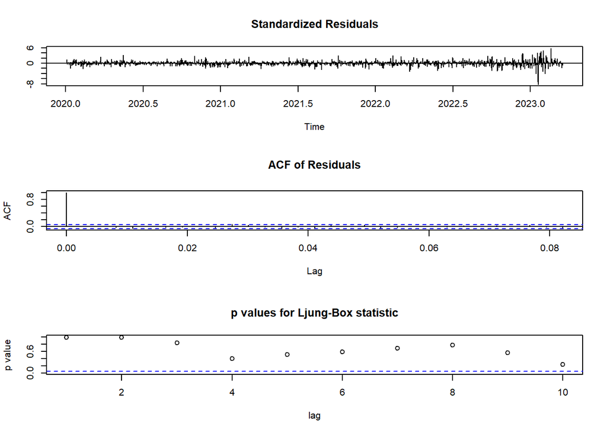

```r
data_sisaan <- model04$residuals
tsdiag(model04)
```

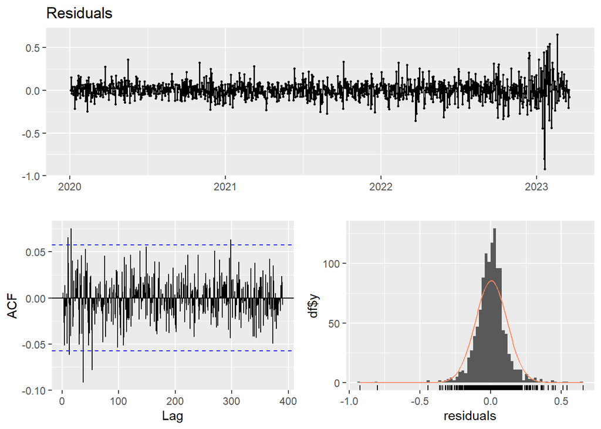

```
##
##  Ljung-Box test
##
## data:  Residuals
## Q* = 198.5, df = 234, p-value = 0.9555
##
## Model df: 0.   Total lags used: 234
```

```r
checkresiduals(model04$residuals)
```

## Uji Q-Q Norm

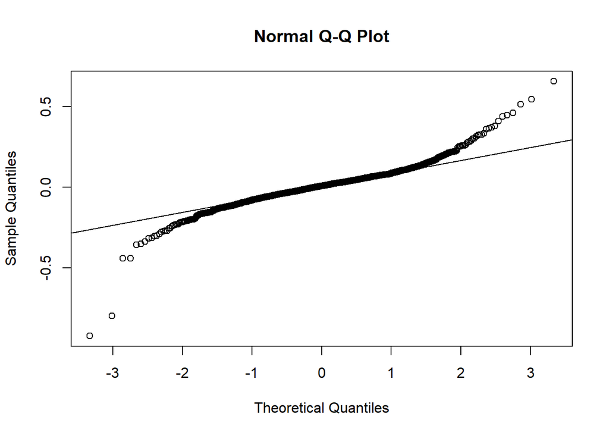

```r
qqnorm(model04$residuals)
qqline(model04$residuals)
```

# Uji Normal

```r
jarque.bera.test(data_sisaan)
```

```
##
##  Jarque Bera Test
##
## data:  data_sisaan
## X-squared = 3862.4, df = 2, p-value < 2.2e-16
```

```r
Box.test(data_sisaan, type = "Ljung")
```

```
##
##  Box-Ljung test
##
## data:  data_sisaan
## X-squared = 0.00074028, df = 1, p-value = 0.9783
```

```r
t.test(data_sisaan, mu = 0, conf.level = 0.95)
```

```
##
##  One Sample t-test
##
## data:  data_sisaan
## t = 1.7027, df = 1170, p-value = 0.08889
## alternative hypothesis: true mean is not equal to 0
## 95 percent confidence interval:
##  -0.0008504425  0.0120198422
## sample estimates:
## mean of x
## 0.0055847
```

# ARCH

```r
arch.test(model04)
```

```
## ARCH heteroscedasticity test for residuals
## alternative: heteroscedastic
##
## Portmanteau-Q test:
##      order  PQ p.value
## [1,]     4 302       0
## [2,]     8 464       0
## [3,]    12 566       0
## [4,]    16 656       0
## [5,]    20 718       0
## [6,]    24 745       0
## Lagrange-Multiplier test:
##      order    LM  p.value
## [1,]     4 786.9 0.00e+00
## [2,]     8 281.3 0.00e+00
## [3,]    12 185.3 0.00e+00
## [4,]    16 117.2 0.00e+00
## [5,]    20  88.7 5.52e-11
## [6,]    24  72.4 5.22e-07
```

[figure not shown]

# Model ARCH

```r
#ARCH(1)
arch1 = garchFit(~ arma(0,2)+garch(1,0), data = saham.diff, trace = F )
summary(arch1)
```

```
##
## Title:
##  GARCH Modelling
##
## Call:
##  garchFit(formula = ~arma(0, 2) + garch(1, 0), data = saham.diff,
##     trace = F)
##
## Mean and Variance Equation:
##  data ~ arma(0, 2) + garch(1, 0)
## <environment: 0x000001b393a20ba8>
##  [data = saham.diff]
##
## Conditional Distribution:
##  norm
##
## Coefficient(s):
##         mu         ma1         ma2       omega      alpha1
##  0.0010239  -0.1069032  -0.0752294   0.0084314   0.2762698
##
## Std. Errors:
##  based on Hessian
##
## Error Analysis:
##          Estimate  Std. Error  t value Pr(>|t|)
## mu      0.0010239   0.0023169    0.442  0.65853
## ma1    -0.1069032   0.0354851   -3.013  0.00259 **
## ma2    -0.0752294   0.0334764   -2.247  0.02462 *
## omega   0.0084314   0.0004316   19.534  < 2e-16 ***
## alpha1  0.2762698   0.0430039    6.424 1.32e-10 ***
## ---
## Signif. codes:  0 '***' 0.001 '**' 0.01 '*' 0.05 '.' 0.1 ' ' 1
##
## Log Likelihood:
##  998.5547    normalized:  0.8527367
##
## Description:
##  Tue Nov  5 23:12:50 2024 by user: RIKA
##
##
## Standardised Residuals Tests:
##                                   Statistic      p-Value
##  Jarque-Bera Test   R    Chi^2  932.8638365 0.000000e+00
##  Shapiro-Wilk Test  R    W        0.9571401 0.000000e+00
##  Ljung-Box Test     R    Q(10)   13.5982294 1.921187e-01
##  Ljung-Box Test     R    Q(15)   16.7817351 3.320789e-01
##  Ljung-Box Test     R    Q(20)   21.5396746 3.660021e-01
##  Ljung-Box Test     R^2  Q(10)   87.3184234 1.820766e-14
##  Ljung-Box Test     R^2  Q(15)  180.6534278 0.000000e+00
##  Ljung-Box Test     R^2  Q(20)  227.3301601 0.000000e+00
##  LM Arch Test       R    TR^2    73.2948767 7.707979e-11
##
## Information Criterion Statistics:
##       AIC       BIC       SIC      HQIC
## -1.696934 -1.675304 -1.696970 -1.688776
```

```r
#ARCH(2)
arch2 = garchFit(~ arma(0,2)+garch(2,0), data = saham.diff, trace = F )
summary(arch2)
```

```
##
## Title:
##  GARCH Modelling
##
## Call:
##  garchFit(formula = ~arma(0, 2) + garch(2, 0), data = saham.diff,
##     trace = F)
##
## Mean and Variance Equation:
##  data ~ arma(0, 2) + garch(2, 0)
## <environment: 0x000001b391eb8180>
##  [data = saham.diff]
##
## Conditional Distribution:
##  norm
##
## Coefficient(s):
##          mu          ma1          ma2        omega       alpha1       alpha2
##  0.00051728  -0.16675859  -0.12962732   0.00667105   0.25308151   0.19574284
##
## Std. Errors:
##  based on Hessian
##
## Error Analysis:
##          Estimate  Std. Error  t value Pr(>|t|)
## mu      0.0005173   0.0019276    0.268 0.788429
## ma1    -0.1667586   0.0367436   -4.538 5.67e-06 ***
## ma2    -0.1296273   0.0336614   -3.851 0.000118 ***
## omega   0.0066711   0.0004731   14.101  < 2e-16 ***
## alpha1  0.2530815   0.0408857    6.190 6.02e-10 ***
## alpha2  0.1957428   0.0486425    4.024 5.72e-05 ***
## ---
## Signif. codes:  0 '***' 0.001 '**' 0.01 '*' 0.05 '.' 0.1 ' ' 1
##
## Log Likelihood:
##  1020.292    normalized:  0.8712998
##
## Description:
##  Tue Nov  5 23:12:50 2024 by user: RIKA
##
##
## Standardised Residuals Tests:
##                                 Statistic      p-Value
##  Jarque-Bera Test   R    Chi^2  450.38038 0.000000e+00
##  Shapiro-Wilk Test  R    W        0.96909 4.220853e-15
##  Ljung-Box Test     R    Q(10)   13.79264 1.826619e-01
##  Ljung-Box Test     R    Q(15)   16.37336 3.576810e-01
##  Ljung-Box Test     R    Q(20)   19.79510 4.708109e-01
##  Ljung-Box Test     R^2  Q(10)   24.51316 6.348807e-03
##  Ljung-Box Test     R^2  Q(15)   78.26620 1.447212e-10
##  Ljung-Box Test     R^2  Q(20)  110.82410 1.387779e-14
##  LM Arch Test       R    TR^2    29.53081 3.283888e-03
##
## Information Criterion Statistics:
##       AIC       BIC       SIC      HQIC
## -1.732352 -1.706397 -1.732404 -1.722563
```

```r
#ARCH(6)
arch6 = garchFit(~ arma(0,2)+garch(1,0), data = saham.diff, trace = F )
summary(arch6)
```

```
##
## Title:
##  GARCH Modelling
##
## Call:
##  garchFit(formula = ~arma(0, 2) + garch(1, 0), data = saham.diff,
##     trace = F)
##
## Mean and Variance Equation:
##  data ~ arma(0, 2) + garch(1, 0)
## <environment: 0x000001b39425fc38>
##  [data = saham.diff]
##
## Conditional Distribution:
##  norm
##
## Coefficient(s):
##         mu         ma1         ma2       omega      alpha1
##  0.0010239  -0.1069032  -0.0752294   0.0084314   0.2762698
##
## Std. Errors:
##  based on Hessian
##
## Error Analysis:
##          Estimate  Std. Error  t value Pr(>|t|)
## mu      0.0010239   0.0023169    0.442  0.65853
## ma1    -0.1069032   0.0354851   -3.013  0.00259 **
## ma2    -0.0752294   0.0334764   -2.247  0.02462 *
## omega   0.0084314   0.0004316   19.534  < 2e-16 ***
## alpha1  0.2762698   0.0430039    6.424 1.32e-10 ***
## ---
## Signif. codes:  0 '***' 0.001 '**' 0.01 '*' 0.05 '.' 0.1 ' ' 1
##
## Log Likelihood:
##  998.5547    normalized:  0.8527367
##
## Description:
##  Tue Nov  5 23:12:50 2024 by user: RIKA
##
##
## Standardised Residuals Tests:
##                                   Statistic      p-Value
##  Jarque-Bera Test   R    Chi^2  932.8638365 0.000000e+00
##  Shapiro-Wilk Test  R    W        0.9571401 0.000000e+00
##  Ljung-Box Test     R    Q(10)   13.5982294 1.921187e-01
##  Ljung-Box Test     R    Q(15)   16.7817351 3.320789e-01
##  Ljung-Box Test     R    Q(20)   21.5396746 3.660021e-01
##  Ljung-Box Test     R^2  Q(10)   87.3184234 1.820766e-14
##  Ljung-Box Test     R^2  Q(15)  180.6534278 0.000000e+00
##  Ljung-Box Test     R^2  Q(20)  227.3301601 0.000000e+00
##  LM Arch Test       R    TR^2    73.2948767 7.707979e-11
##
## Information Criterion Statistics:
##       AIC       BIC       SIC      HQIC
## -1.696934 -1.675304 -1.696970 -1.688776
```

Analisis : Dari ketiga model ARCH yang kita cobakan, nilai p-value dari LM Arch Test menunjukan kurang dari (<) alpha = 0,05. Hal ini mengartikan bahwa data ketiga model diatas belum cukup baik untuk digunakan dalam prediksi model ARCH.

```r
#ARCH(7)
arch7 = garchFit(~ arma(0,2)+garch(7,0), data = saham.diff, trace = F )
summary(arch7)
```

```
##
## Title:
##  GARCH Modelling
##
## Call:
##  garchFit(formula = ~arma(0, 2) + garch(7, 0), data = saham.diff,
##     trace = F)
##
## Mean and Variance Equation:
##  data ~ arma(0, 2) + garch(7, 0)
## <environment: 0x000001b396254e98>
##  [data = saham.diff]
##
## Conditional Distribution:
##  norm
##
## Coefficient(s):
##          mu          ma1          ma2        omega       alpha1       alpha2
##  0.00112136  -0.12012810  -0.07498220   0.00527314   0.23106482   0.06649715
##      alpha3       alpha4       alpha5       alpha6       alpha7
##  0.02553621   0.05559460   0.00000001   0.10450436   0.04801329
##
## Std. Errors:
##  based on Hessian
##
## Error Analysis:
##          Estimate  Std. Error  t value Pr(>|t|)
## mu      1.121e-03   1.567e-03    0.715 0.474340
## ma1    -1.201e-01   3.351e-02   -3.585 0.000337 ***
## ma2    -7.498e-02   3.128e-02   -2.397 0.016526 *
## omega   5.273e-03   3.759e-04   14.029  < 2e-16 ***
## alpha1  2.311e-01   3.227e-02    7.160 8.04e-13 ***
## alpha2  6.650e-02   3.149e-02    2.111 0.034740 *
## alpha3  2.554e-02   2.391e-02    1.068 0.285458
## alpha4  5.559e-02         NaN      NaN      NaN
## alpha5  1.000e-08         NaN      NaN      NaN
## alpha6  1.045e-01   3.484e-02    3.000 0.002701 **
## alpha7  4.801e-02   3.071e-02    1.564 0.117901
## ---
## Signif. codes:  0 '***' 0.001 '**' 0.01 '*' 0.05 '.' 0.1 ' ' 1
```

[output cut: 8 more lines]

```
## Standardised Residuals Tests:
##                                   Statistic      p-Value
##  Jarque-Bera Test   R    Chi^2  254.8095604 0.000000e+00
##  Shapiro-Wilk Test  R    W        0.9758606 4.512886e-13
##  Ljung-Box Test     R    Q(10)   12.4369686 2.568754e-01
##  Ljung-Box Test     R    Q(15)   16.0308182 3.800064e-01
##  Ljung-Box Test     R    Q(20)   19.4233755 4.944789e-01
##  Ljung-Box Test     R^2  Q(10)    6.4368191 7.773264e-01
##  Ljung-Box Test     R^2  Q(15)   13.3139833 5.780600e-01
##  Ljung-Box Test     R^2  Q(20)   18.8064244 5.344388e-01
##  LM Arch Test       R    TR^2     7.5263683 8.209625e-01
##
## Information Criterion Statistics:
##       AIC       BIC       SIC      HQIC
## -1.769072 -1.721487 -1.769246 -1.751125
```

```r
#ARCH(8)
arch8 = garchFit(~ arma(0,2)+garch(8,0), data = saham.diff, trace = F )
summary(arch8)
```

```
##
## Title:
##  GARCH Modelling
##
## Call:
##  garchFit(formula = ~arma(0, 2) + garch(8, 0), data = saham.diff,
##     trace = F)
##
## Mean and Variance Equation:
##  data ~ arma(0, 2) + garch(8, 0)
## <environment: 0x000001b394a448e8>
##  [data = saham.diff]
##
## Conditional Distribution:
##  norm
##
## Coefficient(s):
##          mu          ma1          ma2        omega       alpha1       alpha2
##  0.00037166  -0.12034833  -0.07477424   0.00527508   0.22898172   0.06630252
##      alpha3       alpha4       alpha5       alpha6       alpha7       alpha8
##  0.02594276   0.05432726   0.00000001   0.10422967   0.04659335   0.00359230
##
## Std. Errors:
##  based on Hessian
##
## Error Analysis:
##          Estimate  Std. Error  t value Pr(>|t|)
## mu      3.717e-04   1.379e-03    0.269 0.787576
## ma1    -1.203e-01   3.354e-02   -3.589 0.000333 ***
## ma2    -7.477e-02   3.127e-02   -2.391 0.016783 *
## omega   5.275e-03   3.555e-04   14.837  < 2e-16 ***
## alpha1  2.290e-01   2.993e-02    7.652 1.98e-14 ***
## alpha2  6.630e-02   3.108e-02    2.133 0.032918 *
## alpha3  2.594e-02   2.284e-02    1.136 0.256046
## alpha4  5.433e-02         NaN      NaN      NaN
## alpha5  1.000e-08         NaN      NaN      NaN
## alpha6  1.042e-01   3.450e-02    3.021 0.002522 **
## alpha7  4.659e-02   3.076e-02    1.515 0.129796
## alpha8  3.592e-03   2.104e-02    0.171 0.864411
## ---
```

[output cut: 9 more lines]

```
## Standardised Residuals Tests:
##                                   Statistic      p-Value
##  Jarque-Bera Test   R    Chi^2  259.3077683 0.000000e+00
##  Shapiro-Wilk Test  R    W        0.9756729 3.920461e-13
##  Ljung-Box Test     R    Q(10)   12.4579686 2.555744e-01
##  Ljung-Box Test     R    Q(15)   16.0369122 3.796027e-01
##  Ljung-Box Test     R    Q(20)   19.4102221 4.953228e-01
##  Ljung-Box Test     R^2  Q(10)    6.4683168 7.745036e-01
##  Ljung-Box Test     R^2  Q(15)   13.3623531 5.743319e-01
##  Ljung-Box Test     R^2  Q(20)   18.8602029 5.309290e-01
##  LM Arch Test       R    TR^2     7.5274063 8.208867e-01
##
## Information Criterion Statistics:
##       AIC       BIC       SIC      HQIC
## -1.766870 -1.714960 -1.767078 -1.747292
```

# Prediksi Nilai Saham INDF dengan Model ARCH (8)

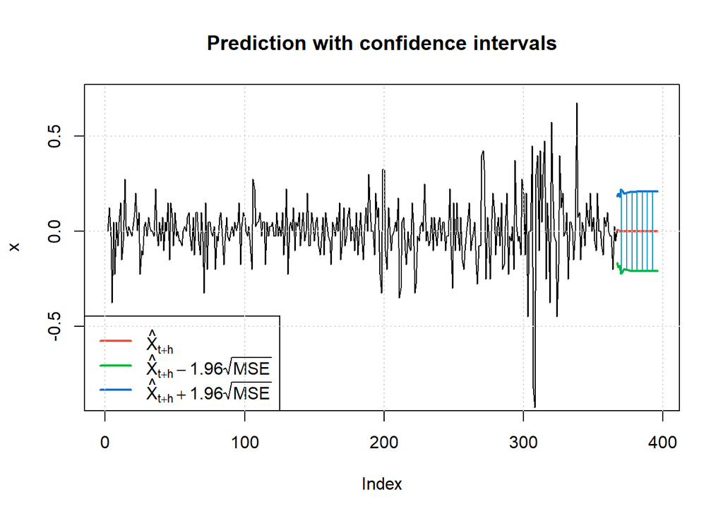

```
##    meanForecast  meanError standardDeviation lowerInterval upperInterval
## 1  0.0084516309 0.08911577        0.08911577    -0.1662121     0.1831153
## 2  0.0053004228 0.09924089        0.09865966    -0.1892081     0.1998090
## 3  0.0003716614 0.09172089        0.09070468    -0.1793980     0.1801413
## 4  0.0003716614 0.11322816        0.11245902    -0.2215515     0.2222948
## 5  0.0003716614 0.10763361        0.10656367    -0.2105863     0.2113297
## 6  0.0003716614 0.10146376        0.10029809    -0.1984936     0.1992370
## 7  0.0003716614 0.10171510        0.10068151    -0.1989863     0.1997296
## 8  0.0003716614 0.10415433        0.10317490    -0.2037671     0.2045104
## 9  0.0003716614 0.10398583        0.10296697    -0.2034368     0.2041802
## 10 0.0003716614 0.10567715        0.10466414    -0.2067517     0.2074951
## 11 0.0003716614 0.10645975        0.10543119    -0.2082856     0.2090289
## 12 0.0003716614 0.10604420        0.10499107    -0.2074711     0.2082145
## 13 0.0003716614 0.10575551        0.10470158    -0.2069053     0.2076486
## 14 0.0003716614 0.10600957        0.10496485    -0.2074033     0.2081466
```

[output cut: 16 more lines]

```r
# Prediksi pada tanggal 1 Desember 2023
predict(arch8, n.ahead=30, plot=TRUE, nx=366)
```